# Geotêxteis: Resumo abrangente

Geotêxteis e Soluções baseadas na Natureza

Prof. Dr. Luiz Diego Vidal Santos

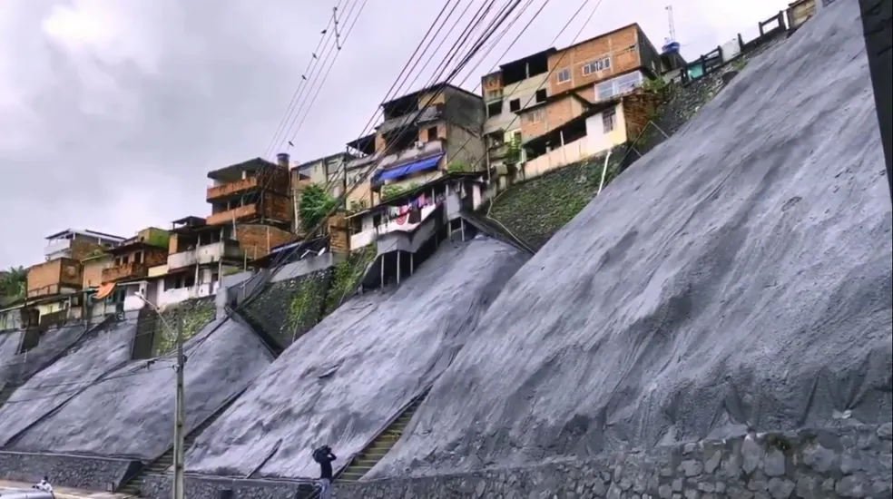

[figure not shown]

- GEOTÊXTEIS - TIPOLOGIA

## Prof. Dr. Diego Vidal

## Do Geossintético ao Geotêxtil

- GEOSSINTÉTICOS
- Geossintéticos são um subconjunto de têxteis industriais ou têxteis técnicos;
- Os têxteis industriais podem ser categorizados de acordo com a **forma** e a **maneira** como as estruturas têxteis são utilizadas (Kaswell, 1963):
- Têxteis Industriais Compostos
- Têxteis Industriais

## Têxteis Industriais de Uso Direto

## Têxteis Industriais de Uso Direto

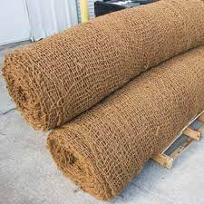

[figure not shown]

[figure not shown]

- GEOTEXTIL -DEFINIÇÃO
- São estruturas têxteis fabricadas ou incorporadas diretamente nos produtos acabados.
- **Biomalha**
- **Geocélula**
- **Biomanta**

## **Exemplos:**

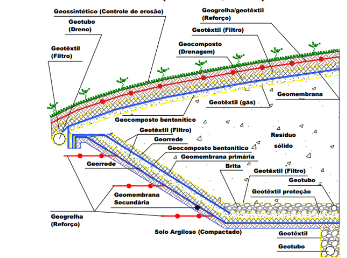

## Definição Geotêxteis (GT)

- GEOTEXTIL -DEFINIÇÃO
- Material têxtil plano, permeável e à base de **polímeros** (natural ou sintético), podendo ser tecido, não tecido ou tricotado, utilizado em** contato com o solo** ou outros materiais em aplicações de engenharia geotécnica.
- **Referência: Frank (2004)**
- **Aterro sanitário**

## **Estruturas Têxteis**

## Desempenha várias funções entre as quais destacam-se:

[figure not shown]

[figure not shown]

- GEOTEXTIL -FUNÇÕES
- **Referências:**
- **NBR 125553:2003**
- **NBR ISO - 10318:2013**
- Reforço;
- Infiltração;
- drenagem proteção;
- Separação;
- impermeabilização
- Controle de erosão

## superficial (laminar);

## Geocélula “Geocell” (GCE)

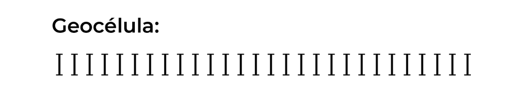

- Estrutura tridimensional, permeável;
- Em forma de casa de abelha ou similar;
- Produzidas a partir de tiras de geossintéticos ligadas entre si.
- **Referência: NBR ISO - 10318:2013**

## GEOTEXTIL - TIPOS POR ESTRUTURA

[figure not shown]

[figure not shown]

[figure not shown]

## **Referência: NBR ISO - 10318:2013**

## Geotêxtil Tipo Geogrelha (GGR)

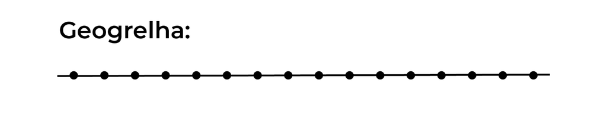

- Estrutura **planar** constituída por uma malha aberta e regular;
- Constituída com elementos resistentes à tração que podem ser unidos por extrusão, solda ou entrelaçamento;
- Suas **aberturas são maiores que os elementos constituintes**.
- **Referência: NBR ISO - 10318:2013**

## GEOTEXTIL - TIPOS POR ESTRUTURA

[figure not shown]

[figure not shown]

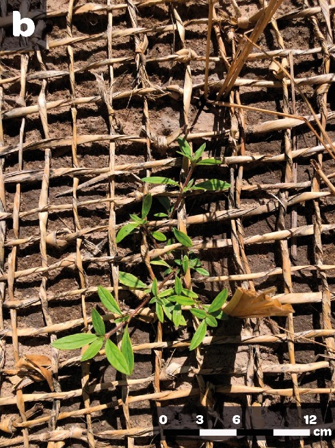

## **Referência: NBR ISO - 10318:2013**

- Permitem a interação com meio que estão confinadas;
- Unidirecional - quando a sua resistência a tração direciona-se para uma direção
- Bidimensional - quando a sua resistência a tração direciona-se para duas direções
- **Referência: NBR ISO - 10318:2013**

## GEOTEXTIL - TIPOS POR ESTRUTURA

## Geotêxtil tipo Geocomposto (GCO)

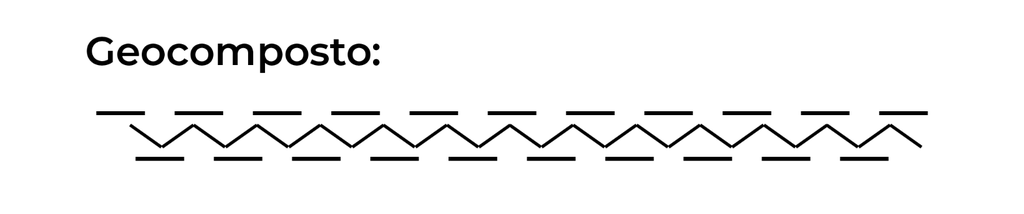

## GEOTEXTIL - TIPOS POR ESTRUTURA

## Geocomposto para Drenagem (GCO-D)

[figure not shown]

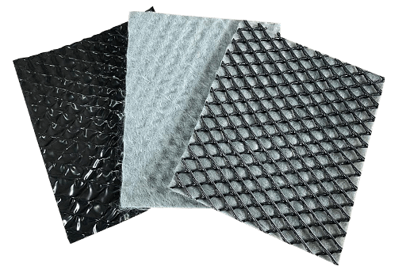

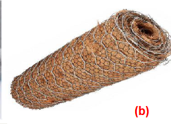

## **Referência: NBR ISO - 10318:2013**

## Geocomposto argiloso para barreira impermeabilizante (GCO-L)

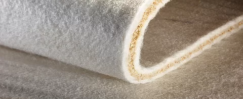

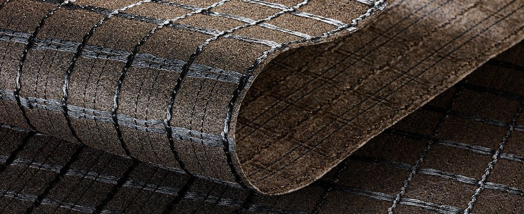

- GEOTEXTIL - TIPOS POR ESTRUTURA
- Formado pela associação de geossintéticos e material argiloso de baixa condutividade;
- Principal função de barreira.

## **Referência: NBR ISO - 10318:2013**

## Geomanta (GBL)

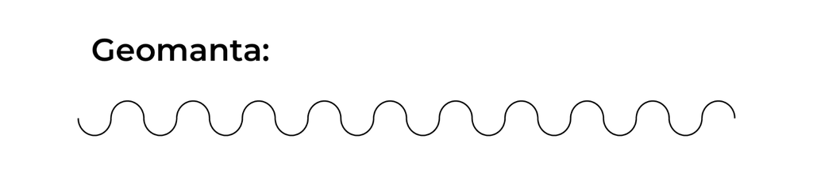

- GEOTEXTIL - TIPOS POR ESTRUTURA
- Estrutura tridimensional **permeável**, constituída de monofilamentos poliméricos e/ou outros elementos, integrados por meio mecânico e/ou outros;
- Conhecido também como: biomanta caso seja biodegradável;
- Utilizados no **controle de erosão**** **superficial do solo.

## **Referência: NBR ISO - 10318:2013**

## Referência: NBR ISO - 10318:2013

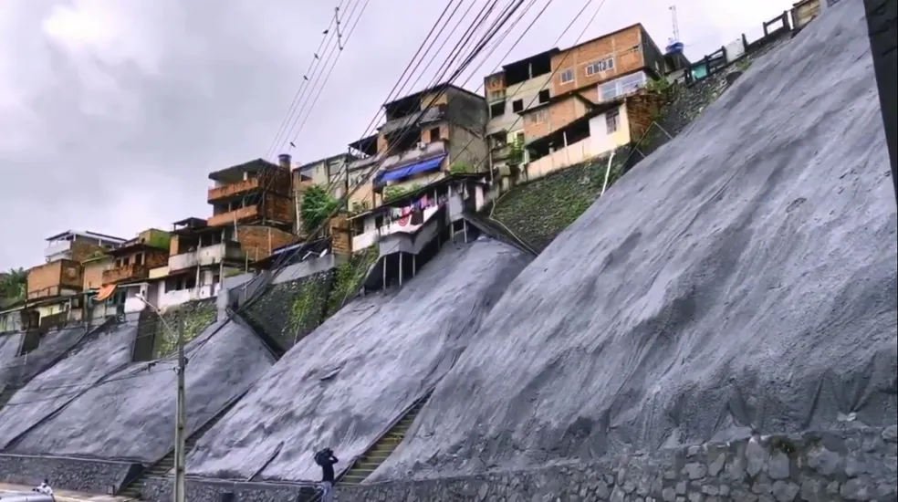

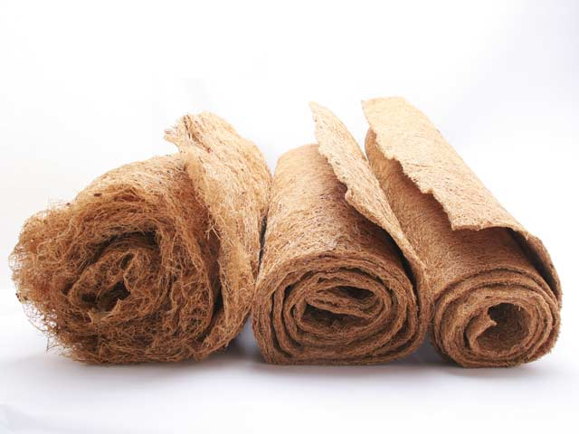

[figure not shown]

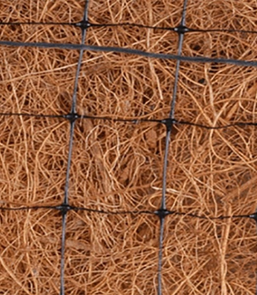

## Geodreno

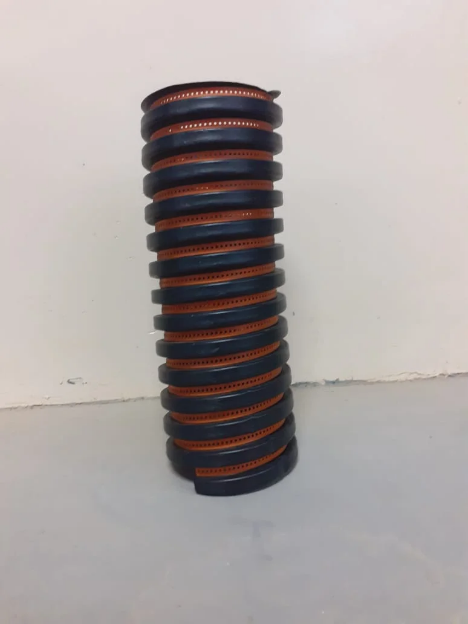

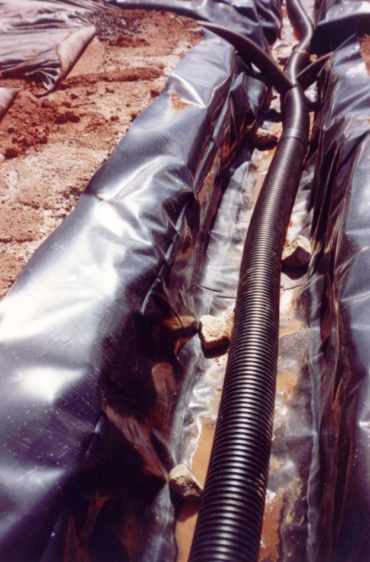

[figure not shown]

- GEOTEXTIL - TIPOS POR ESTRUTURA
- Produto em forma tubular ou semicircular, com função predominantemente drenante.

## **Referência: NBR ISO - 10318:2013**

## Geodreno - Natural

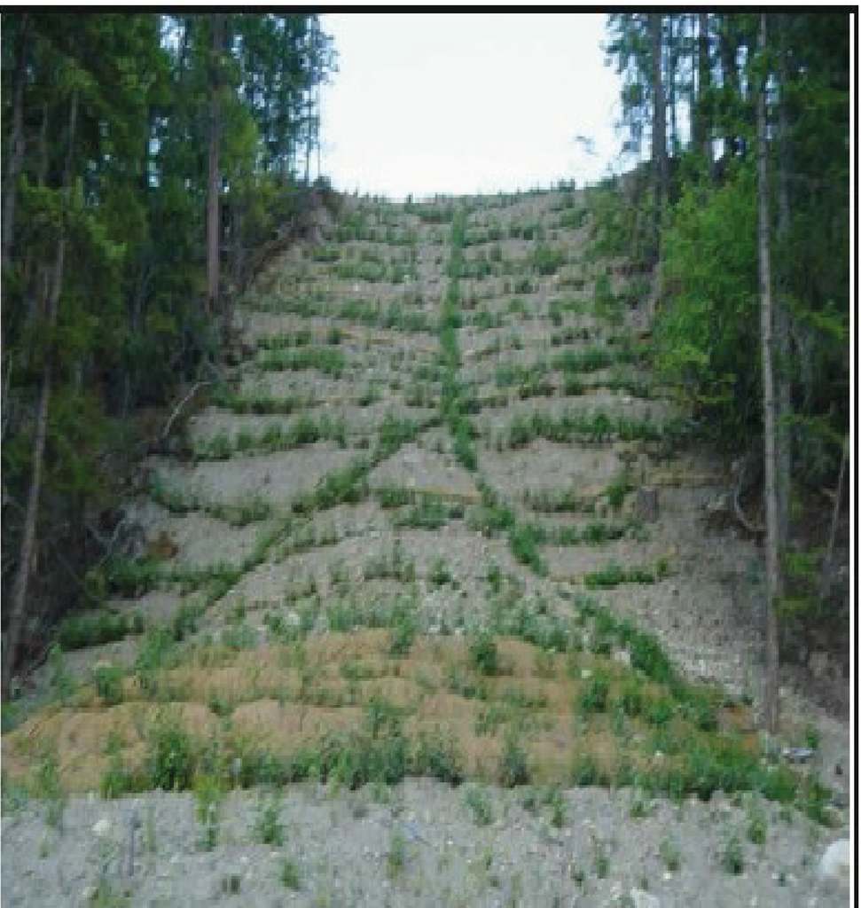

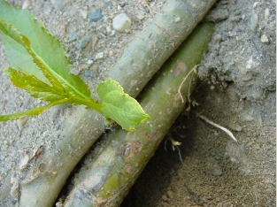

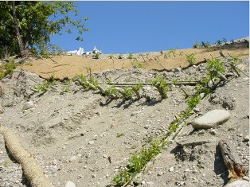

- GEOTEXTIL - TIPOS POR ESTRUTURA
- Estrutura do dreno vivo, tipo “espinha de peixe”;

## Similar ao Geotubo do tipo dreno

## Geomalha (GMA)

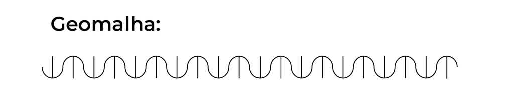

- GEOTEXTIL - TIPOS POR ESTRUTURA
- Um geossintético ou geonatural geralmente com uma estrutura tecida plana;
- Grandes tamanhos de poros, que variam de vários milímetros a vários centímetros para uso principalmente em trabalhos de controle de erosão.